# Spotify Tracks Popularity Prediction

# SMART Questions

The first SMART question for us is “Which features make a song popular?”, and we will determine audio features in a song that affect the popularity. The second question is “Can we recommend a certain song to users who like to listen popular songs?”

# Description of Data

Let us pull the dataset from the file `spotify_dataset.csv` into a dataframe `df_spotify`. As this file is huge in size, we cannot upload it on GitHub. Thus, we are storing the file in a folder called `spotify_dataset` that is located in one folder above the project folder.

```r
df_spotify <- data.frame(read.csv('spotify_dataset.csv'))
str(df_spotify)
```

```
## 'data.frame':    114000 obs. of  21 variables:
##  $ X               : int  0 1 2 3 4 5 6 7 8 9 ...
##  $ track_id        : chr  "5SuOikwiRyPMVoIQDJUgSV" "4qPNDBW1i3p13qLCt0Ki3A" "1iJBSr7s7jYXzM8EGcbK5b" "6lfxq3CG4xtTiEg7opyCyx" ...
##  $ artists         : chr  "Gen Hoshino" "Ben Woodward" "Ingrid Michaelson;ZAYN" "Kina Grannis" ...
##  $ album_name      : chr  "Comedy" "Ghost (Acoustic)" "To Begin Again" "Crazy Rich Asians (Original Motion Picture Soundtrack)" ...
##  $ track_name      : chr  "Comedy" "Ghost - Acoustic" "To Begin Again" "Can't Help Falling In Love" ...
##  $ popularity      : int  73 55 57 71 82 58 74 80 74 56 ...
##  $ duration_ms     : int  230666 149610 210826 201933 198853 214240 229400 242946 189613 205594 ...
##  $ explicit        : chr  "False" "False" "False" "False" ...
##  $ danceability    : num  0.676 0.42 0.438 0.266 0.618 0.688 0.407 0.703 0.625 0.442 ...
##  $ energy          : num  0.461 0.166 0.359 0.0596 0.443 0.481 0.147 0.444 0.414 0.632 ...
##  $ key             : int  1 1 0 0 2 6 2 11 0 1 ...
##  $ loudness        : num  -6.75 -17.23 -9.73 -18.52 -9.68 ...
##  $ mode            : int  0 1 1 1 1 1 1 1 1 1 ...
##  $ speechiness     : num  0.143 0.0763 0.0557 0.0363 0.0526 0.105 0.0355 0.0417 0.0369 0.0295 ...
##  $ acousticness    : num  0.0322 0.924 0.21 0.905 0.469 0.289 0.857 0.559 0.294 0.426 ...
##  $ instrumentalness: num  1.01e-06 5.56e-06 0.00 7.07e-05 0.00 0.00 2.89e-06 0.00 0.00 4.19e-03 ...
##  $ liveness        : num  0.358 0.101 0.117 0.132 0.0829 0.189 0.0913 0.0973 0.151 0.0735 ...
##  $ valence         : num  0.715 0.267 0.12 0.143 0.167 0.666 0.0765 0.712 0.669 0.196 ...
##  $ tempo           : num  87.9 77.5 76.3 181.7 119.9 ...
##  $ time_signature  : int  4 4 4 3 4 4 3 4 4 4 ...
##  $ track_genre     : chr  "acoustic" "acoustic" "acoustic" "acoustic" ...
```

The target variable for us is “Popularity”. It has a range from 0 to 100 and type of integer. The popularity is determined by an algorithm and primarily depends on how recently and how many times the track has been played overall. In general, songs that are played often currently will be more popular than songs that were frequently performed in the past.

```r
head(df_spotify)
```

```
##   X               track_id                artists
## 1 0 5SuOikwiRyPMVoIQDJUgSV            Gen Hoshino
## 2 1 4qPNDBW1i3p13qLCt0Ki3A           Ben Woodward
## 3 2 1iJBSr7s7jYXzM8EGcbK5b Ingrid Michaelson;ZAYN
## 4 3 6lfxq3CG4xtTiEg7opyCyx           Kina Grannis
## 5 4 5vjLSffimiIP26QG5WcN2K       Chord Overstreet
## 6 5 01MVOl9KtVTNfFiBU9I7dc           Tyrone Wells
##                                               album_name
## 1                                                 Comedy
## 2                                       Ghost (Acoustic)
## 3                                         To Begin Again
## 4 Crazy Rich Asians (Original Motion Picture Soundtrack)
## 5                                                Hold On
## 6                                   Days I Will Remember
##                   track_name popularity duration_ms explicit danceability
```

[output cut: 20 more lines]

```r
tail(df_spotify)
```

```
##             X               track_id          artists
## 113995 113994 4WbOUe6T0sozC7z5ZJgiAA   Lucas Cervetti
## 113996 113995 2C3TZjDRiAzdyViavDJ217    Rainy Lullaby
## 113997 113996 1hIz5L4IB9hN3WRYPOCGPw    Rainy Lullaby
## 113998 113997 6x8ZfSoqDjuNa5SVP5QjvX    Cesária Evora
## 113999 113998 2e6sXL2bYv4bSz6VTdnfLs Michael W. Smith
## 114000 113999 2hETkH7cOfqmz3LqZDHZf5    Cesária Evora
##                                                                             album_name
## 113995                                                    Frecuencias Álmicas en 432hz
## 113996 #mindfulness - Soft Rain for Mindful Meditation, Stress Relief Relaxation Music
## 113997 #mindfulness - Soft Rain for Mindful Meditation, Stress Relief Relaxation Music
## 113998                                                                         Best Of
## 113999                                                               Change Your World
## 114000                                                                  Miss Perfumado
##                      track_name popularity duration_ms explicit danceability
```

[output cut: 20 more lines]

```r
summary(df_spotify)
```

```
##        X            track_id           artists           album_name
##  Min.   :     0   Length:114000      Length:114000      Length:114000
##  1st Qu.: 28500   Class :character   Class :character   Class :character
##  Median : 57000   Mode  :character   Mode  :character   Mode  :character
##  Mean   : 57000
##  3rd Qu.: 85499
##  Max.   :113999
##   track_name          popularity      duration_ms        explicit
##  Length:114000      Min.   :  0.00   Min.   :      0   Length:114000
##  Class :character   1st Qu.: 17.00   1st Qu.: 174066   Class :character
##  Mode  :character   Median : 35.00   Median : 212906   Mode  :character
##                     Mean   : 33.24   Mean   : 228029
##                     3rd Qu.: 50.00   3rd Qu.: 261506
##                     Max.   :100.00   Max.   :5237295
##   danceability        energy            key            loudness
##  Min.   :0.0000   Min.   :0.0000   Min.   : 0.000   Min.   :-49.531
##  1st Qu.:0.4560   1st Qu.:0.4720   1st Qu.: 2.000   1st Qu.:-10.013
##  Median :0.5800   Median :0.6850   Median : 5.000   Median : -7.004
##  Mean   :0.5668   Mean   :0.6414   Mean   : 5.309   Mean   : -8.259
##  3rd Qu.:0.6950   3rd Qu.:0.8540   3rd Qu.: 8.000   3rd Qu.: -5.003
##  Max.   :0.9850   Max.   :1.0000   Max.   :11.000   Max.   :  4.532
##       mode         speechiness       acousticness    instrumentalness
##  Min.   :0.0000   Min.   :0.00000   Min.   :0.0000   Min.   :0.00e+00
##  1st Qu.:0.0000   1st Qu.:0.03590   1st Qu.:0.0169   1st Qu.:0.00e+00
##  Median :1.0000   Median :0.04890   Median :0.1690   Median :4.16e-05
##  Mean   :0.6376   Mean   :0.08465   Mean   :0.3149   Mean   :1.56e-01
##  3rd Qu.:1.0000   3rd Qu.:0.08450   3rd Qu.:0.5980   3rd Qu.:4.90e-02
##  Max.   :1.0000   Max.   :0.96500   Max.   :0.9960   Max.   :1.00e+00
##     liveness         valence           tempo        time_signature
##  Min.   :0.0000   Min.   :0.0000   Min.   :  0.00   Min.   :0.000
##  1st Qu.:0.0980   1st Qu.:0.2600   1st Qu.: 99.22   1st Qu.:4.000
##  Median :0.1320   Median :0.4640   Median :122.02   Median :4.000
##  Mean   :0.2136   Mean   :0.4741   Mean   :122.15   Mean   :3.904
##  3rd Qu.:0.2730   3rd Qu.:0.6830   3rd Qu.:140.07   3rd Qu.:4.000
##  Max.   :1.0000   Max.   :0.9950   Max.   :243.37   Max.   :5.000
##  track_genre
##  Length:114000
##  Class :character
##  Mode  :character
##
##
##
```

First, let’s check the percentage of NA’s present in each columns of the dataset.

```r
(colMeans(is.na(df_spotify)))*100
```

```
##                X         track_id          artists       album_name
##                0                0                0                0
##       track_name       popularity      duration_ms         explicit
##                0                0                0                0
##     danceability           energy              key         loudness
##                0                0                0                0
##             mode      speechiness     acousticness instrumentalness
##                0                0                0                0
##         liveness          valence            tempo   time_signature
##                0                0                0                0
##      track_genre
##                0
```

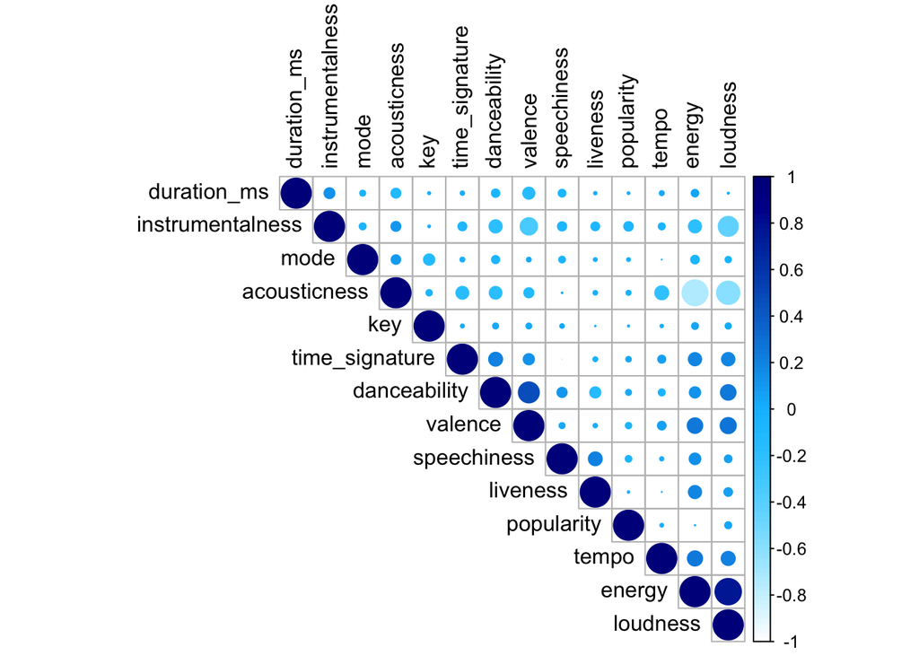

```r
data_corr<-df_spotify %>% select_if(is.numeric)
data_corr = subset(data_corr, select = -c(X) )

corrplot(cor(data_corr),
         type = "upper",
         col = colorRampPalette(c("white", "deepskyblue", "blue4"))(100),
         is.corr = TRUE,
         order = "hclust",
         tl.col = "black",
         diag = TRUE)
```

We haven’t dropped any observations since there are no NA values. The columns ‘track id’ and ‘X’ were dropped since they did not have any useful information.

# DATA Preprocessing

```r
options(dplyr.summarise.inform = FALSE)
missing.values <- df_spotify %>%
    gather(key = "key", value = "val") %>%
    mutate(is.missing = is.na(val)) %>%
    group_by(key, is.missing) %>%
    summarise(num.missing = n()) %>%
    filter(is.missing==T) %>%
    select(-is.missing) %>%
    arrange(desc(num.missing))

missing.values
```

```
## # A tibble: 0 × 2
## # Groups:   key [0]
## # … with 2 variables: key <chr>, num.missing <int>
```

```r
df_spotify<-df_spotify %>%
 mutate(duration_min = duration_ms/60000)

df_spotify$duration_min <- round(df_spotify$duration_min ,digit=2)
head(df_spotify)
```

```
##   X               track_id                artists
## 1 0 5SuOikwiRyPMVoIQDJUgSV            Gen Hoshino
## 2 1 4qPNDBW1i3p13qLCt0Ki3A           Ben Woodward
## 3 2 1iJBSr7s7jYXzM8EGcbK5b Ingrid Michaelson;ZAYN
## 4 3 6lfxq3CG4xtTiEg7opyCyx           Kina Grannis
## 5 4 5vjLSffimiIP26QG5WcN2K       Chord Overstreet
## 6 5 01MVOl9KtVTNfFiBU9I7dc           Tyrone Wells
##                                               album_name
## 1                                                 Comedy
## 2                                       Ghost (Acoustic)
## 3                                         To Begin Again
## 4 Crazy Rich Asians (Original Motion Picture Soundtrack)
## 5                                                Hold On
## 6                                   Days I Will Remember
##                   track_name popularity duration_ms explicit danceability
```

[output cut: 20 more lines]

```r
df_spotify$artists[df_spotify$artists == '['] <- ''
df_spotify$artists[df_spotify$artists == ']']<- ''
df_spotify$artists[df_spotify$artists == "'"]<- ''
head(df_spotify)
```

```
##   X               track_id                artists
## 1 0 5SuOikwiRyPMVoIQDJUgSV            Gen Hoshino
## 2 1 4qPNDBW1i3p13qLCt0Ki3A           Ben Woodward
## 3 2 1iJBSr7s7jYXzM8EGcbK5b Ingrid Michaelson;ZAYN
## 4 3 6lfxq3CG4xtTiEg7opyCyx           Kina Grannis
## 5 4 5vjLSffimiIP26QG5WcN2K       Chord Overstreet
## 6 5 01MVOl9KtVTNfFiBU9I7dc           Tyrone Wells
##                                               album_name
## 1                                                 Comedy
## 2                                       Ghost (Acoustic)
## 3                                         To Begin Again
## 4 Crazy Rich Asians (Original Motion Picture Soundtrack)
## 5                                                Hold On
## 6                                   Days I Will Remember
##                   track_name popularity duration_ms explicit danceability
```

[output cut: 20 more lines]

# EDA

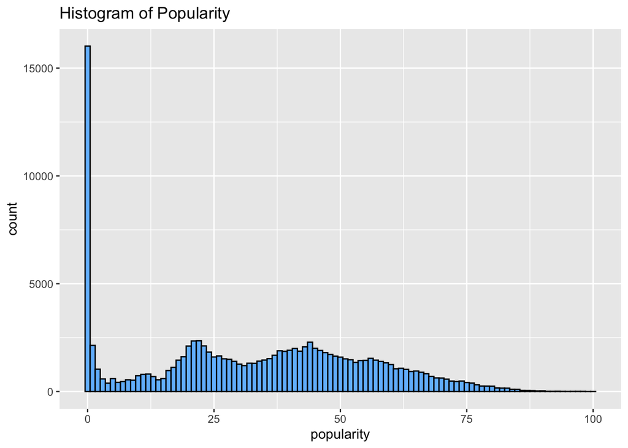

```r
popHist <- ggplot(df_spotify, aes(x=popularity)) + geom_histogram(color="black", fill="steelblue1", alpha=0.9, bins = 101)+
  ggtitle("Histogram of Popularity")
popHist
```

From the histogram of popularity, we can see there are many songs that have popularity of 0, which made 0 as a mode. There are more values from the left-half side than the right-side, which means it’s right skewed.

```r
# made basic histogram & scatterplot for every other variables that we didn't include to our SMART Q

danceHist <- ggplot(df_spotify, aes(x=danceability)) + geom_histogram(fill="steelblue1", alpha=0.9, bins = 150)+
  ggtitle("Histogram of Danceability")


danceSct<- ggplot(df_spotify, aes(x=popularity, y= danceability)) +
  geom_point(colour="steelblue1",size = 0.1) +
  ggtitle("Scatterplot for Danceability")


acHist <- ggplot(df_spotify, aes(x=acousticness)) + geom_histogram( fill="steelblue1", alpha=0.9, bins = 100)+
  ggtitle("Histogram of Acousticness")


acSct<- ggplot(df_spotify, aes(x=popularity, y= acousticness)) +
  geom_point(colour="steelblue1",size = 0.1) +
  ggtitle("Scatterplot for Acousticness")


energyHist <- ggplot(df_spotify, aes(x=energy)) + geom_histogram(fill="steelblue1", alpha=0.9, bins = 100)+
  ggtitle("Histogram of Energy")


energySct<- ggplot(df_spotify, aes(x=popularity, y= energy)) +
  geom_point(colour="steelblue1",size = 0.1) +
  ggtitle("Scatterplot for Energy")


speechinessHist <- ggplot(df_spotify, aes(x=speechiness)) + geom_histogram( fill="steelblue1", alpha=0.9, bins = 100)+
  ggtitle("Histogram of speechiness")


speechinessSct<- ggplot(df_spotify, aes(x=popularity, y= speechiness)) +
  geom_point(colour="steelblue1",size = 0.1) +
  ggtitle("Scatterplot for speechiness")


instrumentalnessHist <- ggplot(df_spotify, aes(x=instrumentalness)) + geom_histogram(fill="steelblue1", alpha=0.9, bins = 50)+
  ggtitle("Histogram of instrumentalness")


instrumentalnessSctr<- ggplot(df_spotify, aes(x=popularity, y= instrumentalness)) +
  geom_point(colour="steelblue1",size = 0.1) +
  ggtitle("Scatterplot for instrumentalness")


livenessHist <- ggplot(df_spotify, aes(x=liveness)) + geom_histogram(fill="steelblue1", alpha=0.9, bins = 100)+
  ggtitle("Histogram of liveness")


livenessSct<- ggplot(df_spotify, aes(x=popularity, y= liveness)) +
  geom_point(colour="steelblue1",size = 0.1) +
  ggtitle("Scatterplot for liveness")


valenceHist <- ggplot(df_spotify, aes(x=valence)) + geom_histogram(fill="steelblue1", alpha=0.9, bins = 100)+
  ggtitle("Histogram of valence")


valenceSctr<- ggplot(df_spotify, aes(x=popularity, y= valence)) +
  geom_point(colour="steelblue1",size = 0.1) +
  ggtitle("Scatterplot for valence")


tempoHist <- ggplot(df_spotify, aes(x=tempo)) + geom_histogram(fill="steelblue1", alpha=0.9, bins = 100)+
  ggtitle("Histogram of tempo")


tempoSctr<- ggplot(df_spotify, aes(x=popularity, y= tempo)) +
  geom_point(colour="steelblue1",size = 0.1) +
  ggtitle("Scatterplot for tempo")
```

We can see the distribution of variables with histograms. There are many right-skewed histograms including the histograms of Accousticness, Speechiness, Liveness, and Instrumentalness. However, for Danceability and Energy, the graphs are left-skewed. For tempo, the graph looks bimodal. And it looks like the Valence has an uniform histogram. By scatterplots, we can see the distribution of each variables with its popularity.

```
## $`1`
```

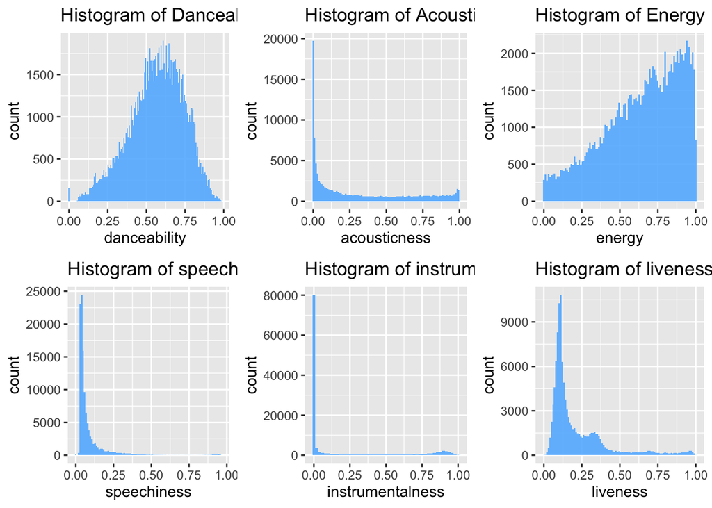

```
##
## $`2`
```

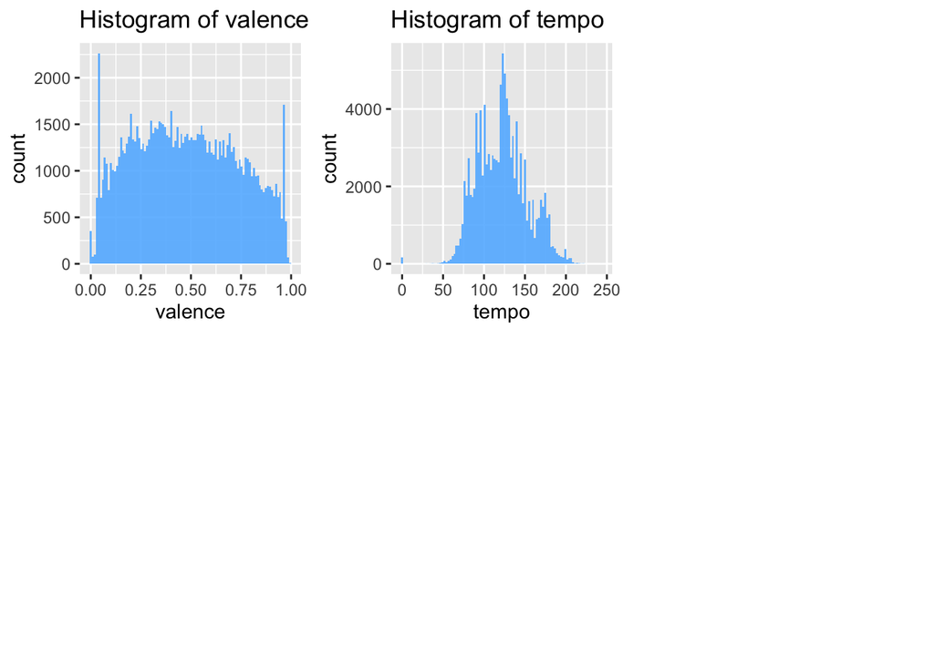

```
##
## attr(,"class")
## [1] "list"      "ggarrange"
```

```r
library("ggpubr")
histfig <- ggarrange(danceHist,acHist,energyHist, speechinessHist, instrumentalnessHist,livenessHist, valenceHist,tempoHist, ncol = 3, nrow = 2)
histfig
```

```r
sctfig <- ggarrange(danceSct, acSct,energySct, speechinessSct, instrumentalnessSctr,livenessSct, valenceSctr,tempoSctr, ncol = 3, nrow = 2)
sctfig
```

```
## $`1`
```

[figure not shown]

```
##
## $`2`
```

[figure not shown]

```
##
## attr(,"class")
## [1] "list"      "ggarrange"
```

```r
data_corr = subset(df_spotify, select = -c(track_id,X) )
data_corr<-df_spotify[!duplicated(df_spotify),]
data_corr = subset(data_corr, select = -c(track_id,X,artists,album_name,track_name,explicit,track_genre) )
```

Here you can see the correlation plot for the features of a song. As we can see in the plot, a lot of features are correlated to each other. For example, energy and loudness, danceability and valence etc. Coming to target variable popularity, it doesn’t really have a strong relation with any of the other features, nonetheless, there is some relationship there. For instance, instrumentalness, danceability, valence etc. We will try to understand these relations in dept in the slides ahead.

```r
valence <- ggplot(data_corr, aes(x=valence)) +
    geom_histogram(aes(y=..density..),      # Histogram with density instead of count on y-axis
                   binwidth=.5,
                   colour="steelblue1", fill="white") +
    geom_density(alpha=.2, fill="steelblue1")

tempo <- ggplot(data_corr, aes(x=tempo)) +
    geom_histogram(aes(y=..density..),      # Histogram with density instead of count on y-axis
                   binwidth=.5,
                   colour="steelblue1", fill="white") +
    geom_density(alpha=.2, fill="steelblue1")

acousticness <- ggplot(data_corr, aes(x=acousticness)) +
    geom_histogram(aes(y=..density..),      # Histogram with density instead of count on y-axis
                   binwidth=.5,
                   colour="steelblue1", fill="white") +
    geom_density(alpha=.2, fill="steelblue1")

danceability <- ggplot(data_corr, aes(x=danceability)) +
    geom_histogram(aes(y=..density..),      # Histogram with density instead of count on y-axis
                   binwidth=.5,
                   colour="steelblue1", fill="white") +
    geom_density(alpha=.2, fill="steelblue1")

speechiness <- ggplot(data_corr, aes(x=speechiness)) +
    geom_histogram(aes(y=..density..),      # Histogram with density instead of count on y-axis
                   binwidth=.5,
                   colour="steelblue1", fill="white") +
    geom_density(alpha=.2, fill="steelblue1")

mode <- ggplot(data_corr, aes(x=mode)) +
    geom_histogram(aes(y=..density..),      # Histogram with density instead of count on y-axis
                   binwidth=.5,
                   colour="steelblue1", fill="white") +
    geom_density(alpha=.2, fill="steelblue1")

liveness <- ggplot(data_corr, aes(x=liveness)) +
    geom_histogram(aes(y=..density..),      # Histogram with density instead of count on y-axis
                   binwidth=.5,
                   colour="steelblue1", fill="white") +
    geom_density(alpha=.2, fill="steelblue1")

loudness <- ggplot(data_corr, aes(x=loudness)) +
    geom_histogram(aes(y=..density..),      # Histogram with density instead of count on y-axis
                   binwidth=.5,
                   colour="steelblue1", fill="white") +
    geom_density(alpha=.2, fill="steelblue1")

popularity <- ggplot(data_corr, aes(x=popularity)) +
    geom_histogram(aes(y=..density..),      # Histogram with density instead of count on y-axis
                   binwidth=.5,
                   colour="steelblue1", fill="white") +
    geom_density(alpha=.2, fill="steelblue1")

energy <- ggplot(data_corr, aes(x=energy)) +
    geom_histogram(aes(y=..density..),      # Histogram with density instead of count on y-axis
                   binwidth=.5,
                   colour="steelblue1", fill="white") +
    geom_density(alpha=.2, fill="steelblue1")


key <- ggplot(data_corr, aes(x=key)) +
    geom_histogram(aes(y=..density..),      # Histogram with density instead of count on y-axis
                   binwidth=.5,
                   colour="steelblue1", fill="white") +
    geom_density(alpha=.2, fill="steelblue1")
```

These are density histograms instead of count on y-axis with numerical variables.

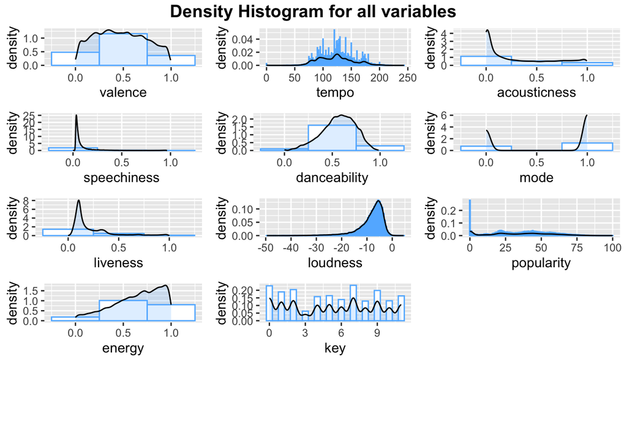

```r
library(ggpubr)
figure <- ggarrange(valence, tempo, acousticness,speechiness, danceability,mode,liveness,loudness,popularity,energy, key, ncol = 3, nrow = 5)
annotate_figure(figure, top = text_grob("Density Histogram for all variables",
               color = "black", face = "bold", size = 14))
```

From the distribution plot, we can observe that, columns such as energy, and valence has high variability where as liveness, danceability, tempo and loudness has relatively lower variability and concentrated in some ranges.

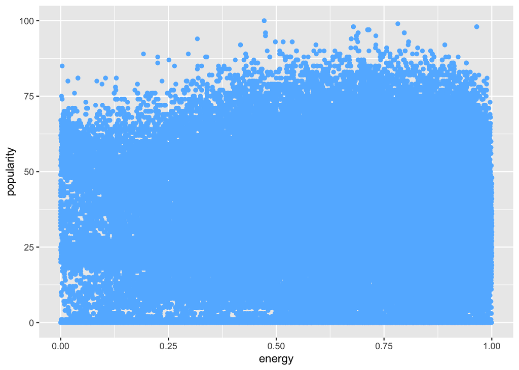

```r
ggplot(data_corr, aes(x=energy, y=popularity)) + geom_point(col = "steelblue1")
```

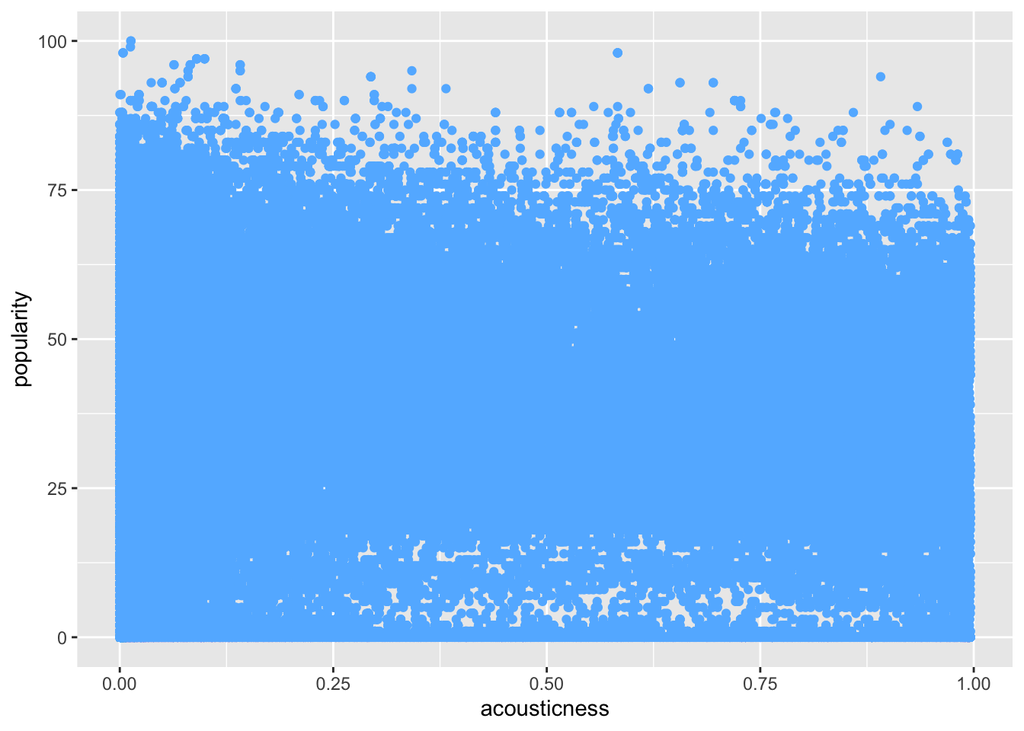

```r
ggplot(data_corr, aes(x=acousticness, y=popularity)) + geom_point(col = "steelblue1")
```

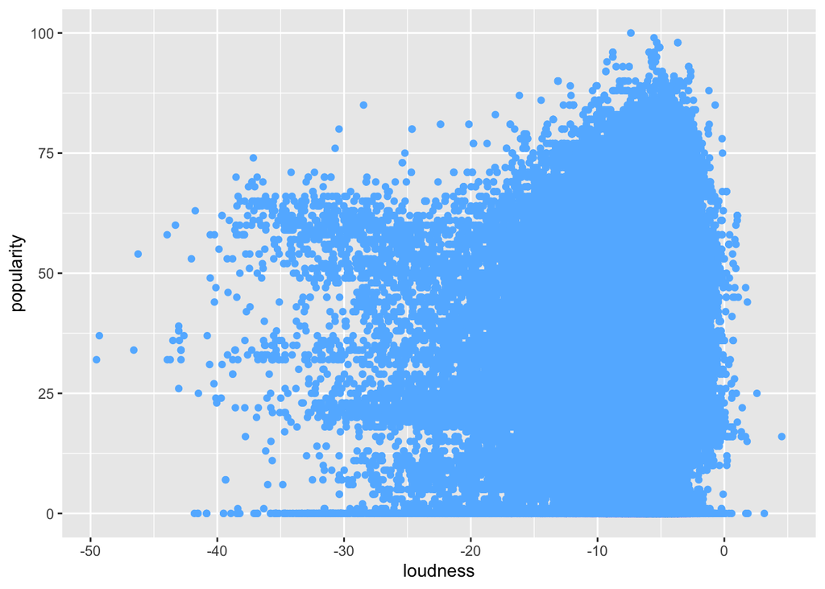

```r
ggplot(data_corr, aes(x=loudness, y=popularity)) + geom_point(col = "steelblue1")
```

```r
data_corr <- data_corr %>% mutate(popularity_t = if_else(popularity > 50, 1, 0))
head(data_corr)
```

```
##   popularity duration_ms danceability energy key loudness mode speechiness
## 1         73      230666        0.676 0.4610   1   -6.746    0      0.1430
## 2         55      149610        0.420 0.1660   1  -17.235    1      0.0763
## 3         57      210826        0.438 0.3590   0   -9.734    1      0.0557
## 4         71      201933        0.266 0.0596   0  -18.515    1      0.0363
## 5         82      198853        0.618 0.4430   2   -9.681    1      0.0526
## 6         58      214240        0.688 0.4810   6   -8.807    1      0.1050
##   acousticness instrumentalness liveness valence   tempo time_signature
## 1       0.0322         1.01e-06   0.3580   0.715  87.917              4
## 2       0.9240         5.56e-06   0.1010   0.267  77.489              4
## 3       0.2100         0.00e+00   0.1170   0.120  76.332              4
## 4       0.9050         7.07e-05   0.1320   0.143 181.740              3
## 5       0.4690         0.00e+00   0.0829   0.167 119.949              4
## 6       0.2890         0.00e+00   0.1890   0.666  98.017              4
##   duration_min popularity_t
## 1         3.84            1
## 2         2.49            1
## 3         3.51            1
## 4         3.37            1
## 5         3.31            1
## 6         3.57            1
```

We have added a new column called popularity_t which is based on popularity feature to have a clear answer for our SMART questions. The top 25% of the popular songs will have 1 value and the rest will have 0.

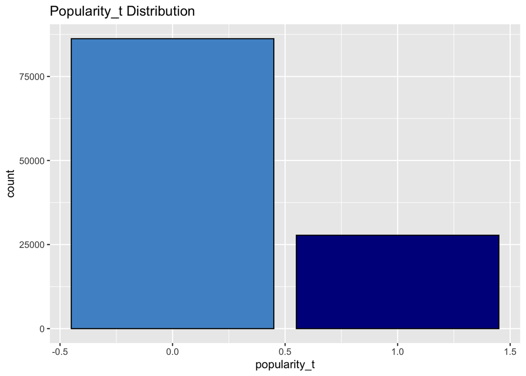

```r
ggplot(data_corr, aes(x = popularity_t, fill=popularity_t)) +
    geom_bar(color="black",fill=c("steelblue3", "blue4"))+
  ggtitle("Popularity_t Distribution")
```

This bar plot represents the new column we have created, popularity_t. The top 25% of the popular songs have 1 value and the rest will have 0. We can observe most of the songs come under 0 category.

```r
pop1 <- subset(data_corr, popularity_t == 1)
pop2 <- subset(data_corr, popularity_t == 0)
str(pop1)
```

```
## 'data.frame':    27770 obs. of  16 variables:
##  $ popularity      : int  73 55 57 71 82 58 74 80 74 56 ...
##  $ duration_ms     : int  230666 149610 210826 201933 198853 214240 229400 242946 189613 205594 ...
##  $ danceability    : num  0.676 0.42 0.438 0.266 0.618 0.688 0.407 0.703 0.625 0.442 ...
##  $ energy          : num  0.461 0.166 0.359 0.0596 0.443 0.481 0.147 0.444 0.414 0.632 ...
##  $ key             : int  1 1 0 0 2 6 2 11 0 1 ...
##  $ loudness        : num  -6.75 -17.23 -9.73 -18.52 -9.68 ...
##  $ mode            : int  0 1 1 1 1 1 1 1 1 1 ...
##  $ speechiness     : num  0.143 0.0763 0.0557 0.0363 0.0526 0.105 0.0355 0.0417 0.0369 0.0295 ...
##  $ acousticness    : num  0.0322 0.924 0.21 0.905 0.469 0.289 0.857 0.559 0.294 0.426 ...
##  $ instrumentalness: num  1.01e-06 5.56e-06 0.00 7.07e-05 0.00 0.00 2.89e-06 0.00 0.00 4.19e-03 ...
##  $ liveness        : num  0.358 0.101 0.117 0.132 0.0829 0.189 0.0913 0.0973 0.151 0.0735 ...
##  $ valence         : num  0.715 0.267 0.12 0.143 0.167 0.666 0.0765 0.712 0.669 0.196 ...
##  $ tempo           : num  87.9 77.5 76.3 181.7 119.9 ...
##  $ time_signature  : int  4 4 4 3 4 4 3 4 4 4 ...
##  $ duration_min    : num  3.84 2.49 3.51 3.37 3.31 3.57 3.82 4.05 3.16 3.43 ...
##  $ popularity_t    : num  1 1 1 1 1 1 1 1 1 1 ...
```

```r
str(pop2)
```

```
## 'data.frame':    86230 obs. of  16 variables:
##  $ popularity      : int  0 0 1 0 0 0 0 0 0 0 ...
##  $ duration_ms     : int  216386 231266 302346 131760 273653 131760 131760 131760 131760 234186 ...
##  $ danceability    : num  0.572 0.796 0.755 0.62 0.633 0.62 0.62 0.62 0.62 0.593 ...
##  $ energy          : num  0.454 0.667 0.454 0.309 0.429 0.309 0.309 0.309 0.309 0.455 ...
##  $ key             : int  3 5 9 5 4 5 5 5 5 6 ...
##  $ loudness        : num  -10.29 -4.83 -9.61 -9.21 -6.78 ...
##  $ mode            : int  1 0 0 1 0 1 1 1 1 1 ...
##  $ speechiness     : num  0.0258 0.0392 0.0352 0.0495 0.0381 0.0495 0.0495 0.0495 0.0495 0.0388 ...
##  $ acousticness    : num  0.477 0.381 0.757 0.788 0.0444 0.788 0.788 0.788 0.788 0.366 ...
##  $ instrumentalness: num  1.37e-05 0.00 0.00 0.00 0.00 0.00 0.00 0.00 0.00 0.00 ...
##  $ liveness        : num  0.0974 0.221 0.236 0.146 0.132 0.146 0.146 0.146 0.146 0.0914 ...
##  $ valence         : num  0.515 0.754 0.33 0.664 0.52 0.664 0.664 0.664 0.664 0.564 ...
##  $ tempo           : num  140 98 120 145 144 ...
##  $ time_signature  : int  4 4 4 4 4 4 4 4 4 4 ...
##  $ duration_min    : num  3.61 3.85 5.04 2.2 4.56 2.2 2.2 2.2 2.2 3.9 ...
##  $ popularity_t    : num  0 0 0 0 0 0 0 0 0 0 ...
```

```r
ttest_dance <- t.test(pop1$danceability, pop2$danceability)
ttest_dance
```

```
##
##  Welch Two Sample t-test
##
## data:  pop1$danceability and pop2$danceability
## t = 18.415, df = 50827, p-value < 2.2e-16
## alternative hypothesis: true difference in means is not equal to 0
## 95 percent confidence interval:
##  0.01880043 0.02327923
## sample estimates:
## mean of x mean of y
## 0.5827147 0.5616748
```

```r
ttest_energy <- t.test(pop1$energy, pop2$energy)
ttest_energy
```

```
##
##  Welch Two Sample t-test
##
## data:  pop1$energy and pop2$energy
## t = -7.7581, df = 49513, p-value = 8.785e-15
## alternative hypothesis: true difference in means is not equal to 0
## 95 percent confidence interval:
##  -0.016347809 -0.009753551
## sample estimates:
## mean of x mean of y
## 0.6315112 0.6445619
```

```r
ttest_loudness <- t.test(pop1$loudness, pop2$loudness)
ttest_loudness
```

```
##
##  Welch Two Sample t-test
##
## data:  pop1$loudness and pop2$loudness
## t = 11.445, df = 46058, p-value < 2.2e-16
## alternative hypothesis: true difference in means is not equal to 0
## 95 percent confidence interval:
##  0.3329218 0.4705143
## sample estimates:
## mean of x mean of y
## -7.955099 -8.356817
```

```r
ttest_speechiness <- t.test(pop1$speechiness, pop2$speechiness)
ttest_speechiness
```

```
##
##  Welch Two Sample t-test
##
## data:  pop1$speechiness and pop2$speechiness
## t = -20.368, df = 70492, p-value < 2.2e-16
## alternative hypothesis: true difference in means is not equal to 0
## 95 percent confidence interval:
##  -0.01333412 -0.01099314
## sample estimates:
##  mean of x  mean of y
## 0.07545150 0.08761513
```

```r
ttest_acousticness <- t.test(pop1$acousticness, pop2$acousticness)
ttest_acousticness
```

```
##
##  Welch Two Sample t-test
##
## data:  pop1$acousticness and pop2$acousticness
## t = -12.394, df = 49915, p-value < 2.2e-16
## alternative hypothesis: true difference in means is not equal to 0
## 95 percent confidence interval:
##  -0.03176481 -0.02309010
## sample estimates:
## mean of x mean of y
## 0.2941638 0.3215913
```

```r
ttest_instrumentalness <- t.test(pop1$instrumentalness, pop2$instrumentalness)
ttest_instrumentalness
```

```
##
##  Welch Two Sample t-test
##
## data:  pop1$instrumentalness and pop2$instrumentalness
## t = -30.628, df = 56478, p-value < 2.2e-16
## alternative hypothesis: true difference in means is not equal to 0
## 95 percent confidence interval:
##  -0.06276323 -0.05521336
## sample estimates:
## mean of x mean of y
## 0.1114306 0.1704189
```

```r
ttest_liveness <- t.test(pop1$liveness, pop2$liveness)
ttest_liveness
```

```
##
##  Welch Two Sample t-test
##
## data:  pop1$liveness and pop2$liveness
## t = -34.294, df = 63174, p-value < 2.2e-16
## alternative hypothesis: true difference in means is not equal to 0
## 95 percent confidence interval:
##  -0.04074555 -0.03633985
## sample estimates:
## mean of x mean of y
## 0.1843990 0.2229417
```

```r
ttest_valence <- t.test(pop1$valence, pop2$valence)
ttest_valence
```

```
##
##  Welch Two Sample t-test
##
## data:  pop1$valence and pop2$valence
## t = -14.323, df = 51425, p-value < 2.2e-16
## alternative hypothesis: true difference in means is not equal to 0
## 95 percent confidence interval:
##  -0.02763238 -0.02098022
## sample estimates:
## mean of x mean of y
## 0.4556829 0.4799892
```

```r
ttest_tempo <- t.test(pop1$tempo, pop2$tempo)
ttest_tempo
```

```
##
##  Welch Two Sample t-test
##
## data:  pop1$tempo and pop2$tempo
## t = -4.5327, df = 48562, p-value = 5.837e-06
## alternative hypothesis: true difference in means is not equal to 0
## 95 percent confidence interval:
##  -1.3165064 -0.5216582
## sample estimates:
## mean of x mean of y
##  121.4526  122.3717
```

```r
ttest_duration_min <- t.test(pop1$duration_min, pop2$duration_min)
ttest_duration_min
```

```
##
##  Welch Two Sample t-test
##
## data:  pop1$duration_min and pop2$duration_min
## t = -17.214, df = 73866, p-value < 2.2e-16
## alternative hypothesis: true difference in means is not equal to 0
## 95 percent confidence interval:
##  -0.1900797 -0.1512196
## sample estimates:
## mean of x mean of y
##  3.671387  3.842037
```

```r
ttest_duration_ms <- t.test(pop1$duration_ms, pop2$duration_ms)
ttest_duration_ms
```

```
##
##  Welch Two Sample t-test
##
## data:  pop1$duration_ms and pop2$duration_ms
## t = -17.215, df = 73865, p-value < 2.2e-16
## alternative hypothesis: true difference in means is not equal to 0
## 95 percent confidence interval:
##  -11405.089  -9073.481
## sample estimates:
## mean of x mean of y
##  220284.1  230523.4
```

```r
str(data_corr)
```

```
## 'data.frame':    114000 obs. of  16 variables:
##  $ popularity      : int  73 55 57 71 82 58 74 80 74 56 ...
##  $ duration_ms     : int  230666 149610 210826 201933 198853 214240 229400 242946 189613 205594 ...
##  $ danceability    : num  0.676 0.42 0.438 0.266 0.618 0.688 0.407 0.703 0.625 0.442 ...
##  $ energy          : num  0.461 0.166 0.359 0.0596 0.443 0.481 0.147 0.444 0.414 0.632 ...
##  $ key             : int  1 1 0 0 2 6 2 11 0 1 ...
##  $ loudness        : num  -6.75 -17.23 -9.73 -18.52 -9.68 ...
##  $ mode            : int  0 1 1 1 1 1 1 1 1 1 ...
##  $ speechiness     : num  0.143 0.0763 0.0557 0.0363 0.0526 0.105 0.0355 0.0417 0.0369 0.0295 ...
##  $ acousticness    : num  0.0322 0.924 0.21 0.905 0.469 0.289 0.857 0.559 0.294 0.426 ...
##  $ instrumentalness: num  1.01e-06 5.56e-06 0.00 7.07e-05 0.00 0.00 2.89e-06 0.00 0.00 4.19e-03 ...
##  $ liveness        : num  0.358 0.101 0.117 0.132 0.0829 0.189 0.0913 0.0973 0.151 0.0735 ...
##  $ valence         : num  0.715 0.267 0.12 0.143 0.167 0.666 0.0765 0.712 0.669 0.196 ...
##  $ tempo           : num  87.9 77.5 76.3 181.7 119.9 ...
##  $ time_signature  : int  4 4 4 3 4 4 3 4 4 4 ...
##  $ duration_min    : num  3.84 2.49 3.51 3.37 3.31 3.57 3.82 4.05 3.16 3.43 ...
##  $ popularity_t    : num  1 1 1 1 1 1 1 1 1 1 ...
```

```r
unique(data_corr$popularity_t)
```

```
## [1] 1 0
```

```r
poptfactor <- data_corr
poptfactor$popularity_t <- as.factor(data_corr$popularity_t)

boxt <- ggplot(poptfactor, aes(x=popularity_t, y=tempo,fill=popularity_t)) +
  geom_boxplot(fill=c("steelblue1","blue4")) +
  ggtitle("boxplot for tempo")

boxdu <-ggplot(poptfactor, aes(x=popularity_t, y=duration_ms,fill=popularity_t)) +
  geom_boxplot(fill=c("steelblue1","blue4")) +
  ggtitle("boxplot for duration_ms")

boxv <-ggplot(poptfactor, aes(x=popularity_t, y=valence,fill=popularity_t)) +
  geom_boxplot(fill=c("steelblue1","blue4")) +
  ggtitle("boxplot for valence")

boxi <-ggplot(poptfactor, aes(x=popularity_t, y=instrumentalness,fill=popularity_t)) +
  geom_boxplot(fill=c("steelblue1","blue4")) +
  ggtitle("boxplot for instrumentalness")

boxa <-ggplot(poptfactor, aes(x=popularity_t, y=acousticness,fill=popularity_t)) +
  geom_boxplot(fill=c("steelblue1","blue4")) +
  ggtitle("boxplot for acousticness")

boxda <-ggplot(poptfactor, aes(x=popularity_t, y=danceability,fill=popularity_t)) +
  geom_boxplot(fill=c("steelblue1","blue4")) +
  ggtitle("boxplot for danceability")

boxe <-ggplot(poptfactor, aes(x=popularity_t, y=energy,fill=popularity_t)) +
  geom_boxplot(fill=c("steelblue1","blue4")) +
  ggtitle("boxplot for energy")

boxlo <-ggplot(poptfactor, aes(x=popularity_t, y=loudness,fill=popularity_t)) +
  geom_boxplot(fill=c("steelblue1","blue4")) +
  ggtitle("boxplot for loudness")

boxv <-ggplot(poptfactor, aes(x=popularity_t, y=valence,fill=popularity_t)) +
  geom_boxplot(fill=c("steelblue1","blue4")) +
  ggtitle("boxplot for valence")

boxi <-ggplot(poptfactor, aes(x=popularity_t, y=instrumentalness,fill=popularity_t)) +
  geom_boxplot( fill=c("steelblue1","blue4")) +
  ggtitle("boxplot for instrumentalness")

boxa <-ggplot(poptfactor, aes(x=popularity_t, y=acousticness,fill=popularity_t)) +
  geom_boxplot(fill=c("steelblue1","blue4")) +
  ggtitle("boxplot for acousticness")

boxda <-ggplot(poptfactor, aes(x=popularity_t, y=danceability,fill=popularity_t)) +
  geom_boxplot(fill=c("steelblue1","blue4")) +
  ggtitle("boxplot for danceability")

boxe <-ggplot(poptfactor, aes(x=popularity_t, y=energy,fill=popularity_t)) +
  geom_boxplot(fill=c("steelblue1","blue4")) +
  ggtitle("boxplot for energy")

boxlo <-ggplot(poptfactor, aes(x=popularity_t, y=loudness,fill=popularity_t)) +
  geom_boxplot(fill=c("steelblue1","blue4")) +
  ggtitle("boxplot for loudness")

boxs <-ggplot(poptfactor, aes(x=popularity_t, y=speechiness,fill=popularity_t)) +
  geom_boxplot( fill=c("steelblue1","blue4")) +
  ggtitle("boxplot for speechiness")

boxli <-ggplot(poptfactor, aes(x=popularity_t, y=liveness,fill=popularity_t)) +
  geom_boxplot(fill=c("steelblue1","blue4")) +
  ggtitle("boxplot for liveness")
```

These are boxplots for each numerical variable that separated by its popularity level.

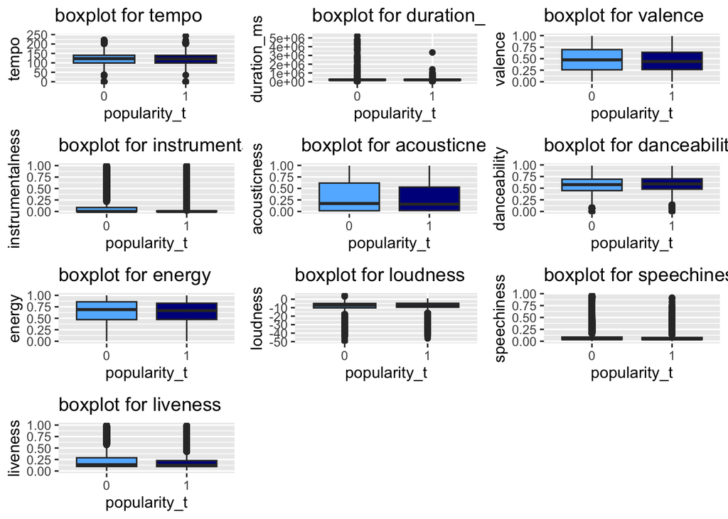

```r
boxforvar <- ggarrange(boxt, boxdu, boxv,boxi,boxa,boxda,boxe,boxlo,boxs, boxli, ncol = 3, nrow = 4)
boxforvar
```

```r
chi_key <- chisq.test(table(data_corr$popularity_t, data_corr$key))
chi_key
```

```
##
##  Pearson's Chi-squared test
##
## data:  table(data_corr$popularity_t, data_corr$key)
## X-squared = 190.31, df = 11, p-value < 2.2e-16
```

```r
chi_mode <- chisq.test(table(data_corr$popularity_t, data_corr$mode))
chi_mode
```

```
##
##  Pearson's Chi-squared test with Yates' continuity correction
##
## data:  table(data_corr$popularity_t, data_corr$mode)
## X-squared = 78.261, df = 1, p-value < 2.2e-16
```

```r
chi_time_signature <- chisq.test(table(data_corr$popularity_t, data_corr$time_signature))
chi_time_signature
```

```
##
##  Pearson's Chi-squared test
##
## data:  table(data_corr$popularity_t, data_corr$time_signature)
## X-squared = 182.05, df = 4, p-value < 2.2e-16
```

Since we have popularity t which is categorical value, we performed the chi-square test with categorical variables which is key, mode, and time signature.  
The null hypothesis here are will be whether the song is popular or not is independent with key/mode/time signature. The alternate hypothesis are they are NOT independent. From the tests, the p-values are small enough to reject the null, which means that they are dependent.

```r
unique(pop1$key)
```

```
##  [1]  1  0  2  6 11  8  4  7  3 10  5  9
```

```r
unique(pop1$mode)
```

```
## [1] 0 1
```

```r
unique(pop1$time_signature)
```

```
## [1] 4 3 1 5 0
```

```r
mode1 <- subset(data_corr, mode == 1)
mode0 <- subset(data_corr, mode == 0)
str(mode1)
```

```
## 'data.frame':    72681 obs. of  16 variables:
##  $ popularity      : int  55 57 71 82 58 74 80 74 56 74 ...
##  $ duration_ms     : int  149610 210826 201933 198853 214240 229400 242946 189613 205594 244800 ...
##  $ danceability    : num  0.42 0.438 0.266 0.618 0.688 0.407 0.703 0.625 0.442 0.627 ...
##  $ energy          : num  0.166 0.359 0.0596 0.443 0.481 0.147 0.444 0.414 0.632 0.363 ...
##  $ key             : int  1 0 0 2 6 2 11 0 1 8 ...
##  $ loudness        : num  -17.23 -9.73 -18.52 -9.68 -8.81 ...
##  $ mode            : int  1 1 1 1 1 1 1 1 1 1 ...
##  $ speechiness     : num  0.0763 0.0557 0.0363 0.0526 0.105 0.0355 0.0417 0.0369 0.0295 0.0291 ...
##  $ acousticness    : num  0.924 0.21 0.905 0.469 0.289 0.857 0.559 0.294 0.426 0.279 ...
##  $ instrumentalness: num  5.56e-06 0.00 7.07e-05 0.00 0.00 2.89e-06 0.00 0.00 4.19e-03 0.00 ...
##  $ liveness        : num  0.101 0.117 0.132 0.0829 0.189 0.0913 0.0973 0.151 0.0735 0.0928 ...
##  $ valence         : num  0.267 0.12 0.143 0.167 0.666 0.0765 0.712 0.669 0.196 0.301 ...
##  $ tempo           : num  77.5 76.3 181.7 119.9 98 ...
##  $ time_signature  : int  4 4 3 4 4 3 4 4 4 4 ...
##  $ duration_min    : num  2.49 3.51 3.37 3.31 3.57 3.82 4.05 3.16 3.43 4.08 ...
##  $ popularity_t    : num  1 1 1 1 1 1 1 1 1 1 ...
```

```r
str(mode0)
```

```
## 'data.frame':    41319 obs. of  16 variables:
##  $ popularity      : int  73 52 54 0 1 0 0 0 0 46 ...
##  $ duration_ms     : int  230666 198712 169728 231266 302346 273653 257493 257493 266960 213098 ...
##  $ danceability    : num  0.676 0.489 0.795 0.796 0.755 0.633 0.409 0.409 0.568 0.596 ...
##  $ energy          : num  0.461 0.314 0.0841 0.667 0.454 0.429 0.153 0.153 0.301 0.2 ...
##  $ key             : int  1 7 10 5 9 4 6 6 10 0 ...
##  $ loudness        : num  -6.75 -9.24 -18.09 -4.83 -9.61 ...
##  $ mode            : int  0 0 0 0 0 0 0 0 0 0 ...
##  $ speechiness     : num  0.143 0.0331 0.0461 0.0392 0.0352 0.0381 0.0306 0.0306 0.0373 0.0305 ...
##  $ acousticness    : num  0.0322 0.749 0.742 0.381 0.757 0.0444 0.939 0.939 0.796 0.91 ...
##  $ instrumentalness: num  1.01e-06 0.00 1.17e-05 0.00 0.00 0.00 2.56e-05 2.56e-05 3.37e-06 1.83e-04 ...
##  $ liveness        : num  0.358 0.113 0.0853 0.221 0.236 0.132 0.108 0.108 0.118 0.0884 ...
##  $ valence         : num  0.715 0.607 0.609 0.754 0.33 0.52 0.18 0.18 0.142 0.308 ...
##  $ tempo           : num  87.9 124.2 91.8 98 120.1 ...
##  $ time_signature  : int  4 4 4 4 4 4 4 4 4 4 ...
##  $ duration_min    : num  3.84 3.31 2.83 3.85 5.04 4.56 4.29 4.29 4.45 3.55 ...
##  $ popularity_t    : num  1 1 1 0 0 0 0 0 0 0 ...
```

```r
ttest_mode <- t.test(mode1$popularity, mode0$popularity)
ttest_mode
```

```
##
##  Welch Two Sample t-test
##
## data:  mode1$popularity and mode0$popularity
## t = -4.6709, df = 84062, p-value = 3.003e-06
## alternative hypothesis: true difference in means is not equal to 0
## 95 percent confidence interval:
##  -0.9176289 -0.3751582
## sample estimates:
## mean of x mean of y
##  33.00425  33.65064
```

```r
aovtime_signature <- aov(popularity ~ time_signature, data = data_corr)
summary(aovtime_signature)
```

```
##                    Df   Sum Sq Mean Sq F value Pr(>F)
## time_signature      1    54761   54761   110.2 <2e-16 ***
## Residuals      113998 56661626     497
## ---
## Signif. codes:  0 '***' 0.001 '**' 0.01 '*' 0.05 '.' 0.1 ' ' 1
```

#Model Building

##Feature Selection

We made an effort to decide which features should be present before developing a model. As a result, we tried to see the Mallow’s Cp statistic and performed feature selection. In contrast, when we chose our features based on the lowest Cp value, we obtained an excessively high accuracy score, indicating that the model was over-fitted. Therefore, we made the decision to construct a complete model with all the features.

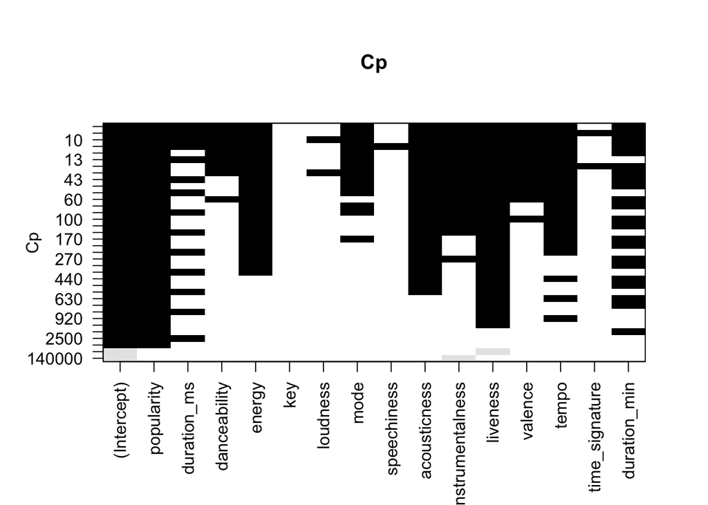

```r
library("leaps")
reg2.best <- regsubsets(popularity_t~. , data = data_corr, nvmax = 12, nbest = 3, method = "exhaustive")
plot(reg2.best, scale = "Cp", main = "Cp")
```

From the above plot we can see that the best features are acousticness, danceability, duration_min, energy,instrumentalness, liveness, mode, tempo, valence.

## Spliting the data

We are splitting our data into test and train data to evaluate our model performance and we are dropping popularity and duration_ms as we have already classified the popularity and converted our milliseconds into minutes.

```r
set.seed(123)
dat.d <- sample(1:nrow(data_corr),size=nrow(data_corr)*0.8,replace = FALSE) #random selection of 70% data.

data_corr.a = subset(data_corr, select = c(-popularity,-duration_ms) )


train <- data_corr.a[dat.d,] # 80% training data
test <- data_corr.a[-dat.d,] # remaining 20% test data
```

## KNN

### Labels for knn

```r
library(class)
prc_train_labels <- train[,14]
prc_test_labels<- test[,14]
```

### Selecting the correct “k”

How does “k” affect classification accuracy? Let’s create a function to calculate classification accuracy based on the number of “k.”

```r
chooseK = function(k, train_set, val_set, train_class, val_class){

  # Build knn with k neighbors considered.
  set.seed(1)
  class_knn = knn(train = train_set,    #<- training set cases
                  test = val_set,       #<- test set cases
                  cl = train_class,     #<- category for classification
                  k = k) #,                #<- number of neighbors considered
                  # use.all = TRUE)       #<- control ties between class assignments. If true, all distances equal to the k-th largest are included

  tab = table(class_knn, val_class)

  # Calculate the accuracy.
  accu = sum(tab[row(tab) == col(tab)]) / sum(tab)
  cbind(k = k, accuracy = accu)
}

# The sapply() function plugs in several values into our chooseK function.
# function(x)[function] allows you to apply a series of numbers
# to a function without running a for() loop.
knn_different_k = sapply(seq(3, 15, by = 2),  #<- set k to be odd number from 1 to 21
                         function(x) chooseK(x,
                                             train_set = train,
                                             val_set = test,
                                             train_class = prc_train_labels,
                                             val_class = prc_test_labels))

# Reformat the results to graph the results.
str(knn_different_k)
```

```
##  num [1:2, 1:7] 3 0.926 5 0.92 7 ...
```

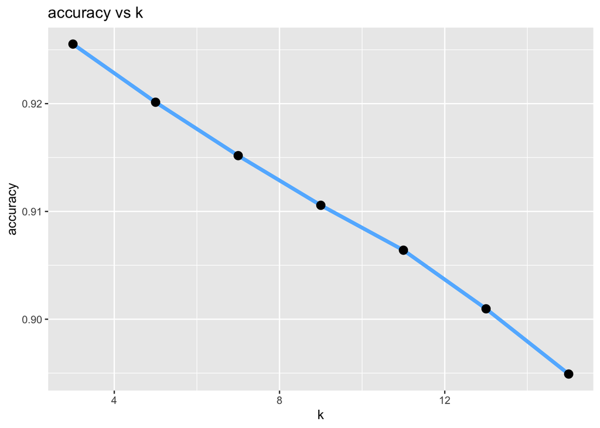

```r
knn_different_k = data.frame(k = knn_different_k[1,],
                             accuracy = knn_different_k[2,])

# Plot accuracy vs. k.
# install.packages("ggplot2")
loadPkg("ggplot2")

ggplot(knn_different_k,
       aes(x = k, y = accuracy)) +
  geom_line(color = "steelblue1", size = 1.5) +
  geom_point(size = 3) +
  labs(title = "accuracy vs k")
```

From the above results we can observe that for value k=3, we are getting the maximum accuracy. We shall go forward and evaluate the model performance by plotting the confusion matrix and summary of the model.

```r
prc_test_pred <- knn(train = train, test = test,cl = prc_train_labels, k=3)
```

```r
cm_knn<-confusionMatrix(as.factor(prc_test_labels),as.factor(prc_test_pred))
cm_knn
```

```
## Confusion Matrix and Statistics
##
##           Reference
## Prediction     0     1
##          0 16767   468
##          1  1211  4354
##
##                Accuracy : 0.9264
##                  95% CI : (0.9229, 0.9297)
##     No Information Rate : 0.7885
##     P-Value [Acc > NIR] : < 2.2e-16
##
##                   Kappa : 0.791
##
##  Mcnemar's Test P-Value : < 2.2e-16
##
##             Sensitivity : 0.9326
##             Specificity : 0.9029
##          Pos Pred Value : 0.9728
##          Neg Pred Value : 0.7824
##              Prevalence : 0.7885
##          Detection Rate : 0.7354
##    Detection Prevalence : 0.7559
##       Balanced Accuracy : 0.9178
##
##        'Positive' Class : 0
##
```

## Decision Tree

```r
library(rpart)
library(rpart.plot)

fit <- rpart(popularity_t~., data = train, method = 'class')

summary(fit)
```

```
## Call:
## rpart(formula = popularity_t ~ ., data = train, method = "class")
##   n= 91200
##
##   CP nsplit rel error xerror xstd
## 1  0      0         1      0    0
##
## Node number 1: 91200 observations
##   predicted class=0  expected loss=0.2434759  P(node) =1
##     class counts: 68995 22205
##    probabilities: 0.757 0.243
```

```r
predict_unseen <-predict(fit, test, type = 'class')
table_mat <- table(test$popularity_t, predict_unseen)
table_mat
```

```
##    predict_unseen
##         0     1
##   0 17235     0
##   1  5565     0
```

```r
cm_dt<-confusionMatrix(as.factor(test$popularity_t),as.factor(predict_unseen))
cm_dt
```

```
## Confusion Matrix and Statistics
##
##           Reference
## Prediction     0     1
##          0 17235     0
##          1  5565     0
##
##                Accuracy : 0.7559
##                  95% CI : (0.7503, 0.7615)
##     No Information Rate : 1
##     P-Value [Acc > NIR] : 1
##
##                   Kappa : 0
##
##  Mcnemar's Test P-Value : <2e-16
##
##             Sensitivity : 0.7559
##             Specificity :     NA
##          Pos Pred Value :     NA
##          Neg Pred Value :     NA
##              Prevalence : 1.0000
##          Detection Rate : 0.7559
##    Detection Prevalence : 0.7559
##       Balanced Accuracy :     NA
##
##        'Positive' Class : 0
##
```

## Logistic Regression Model

```r
model = glm(popularity_t~.,data=train )

summary(model)
```

```
##
## Call:
## glm(formula = popularity_t ~ ., data = train)
##
## Deviance Residuals:
##      Min        1Q    Median        3Q       Max
## -0.46379  -0.27455  -0.21302   0.00628   1.32923
##
## Coefficients:
##                    Estimate Std. Error t value Pr(>|t|)
## (Intercept)       0.4386627  0.0188736  23.242  < 2e-16 ***
## danceability      0.1546069  0.0099987  15.463  < 2e-16 ***
## energy           -0.1104804  0.0114793  -9.624  < 2e-16 ***
## key              -0.0003459  0.0003970  -0.871  0.38353
## loudness          0.0013943  0.0005039   2.767  0.00565 **
## mode             -0.0236234  0.0029696  -7.955 1.81e-15 ***
## speechiness      -0.1866142  0.0140486 -13.283  < 2e-16 ***
## acousticness     -0.0836316  0.0065397 -12.788  < 2e-16 ***
## instrumentalness -0.1480937  0.0054706 -27.071  < 2e-16 ***
## liveness         -0.1534300  0.0078735 -19.487  < 2e-16 ***
## valence          -0.1713455  0.0067678 -25.318  < 2e-16 ***
## tempo            -0.0001485  0.0000488  -3.043  0.00234 **
## time_signature    0.0140412  0.0033531   4.187 2.82e-05 ***
## duration_min     -0.0108261  0.0008038 -13.469  < 2e-16 ***
## ---
## Signif. codes:  0 '***' 0.001 '**' 0.01 '*' 0.05 '.' 0.1 ' ' 1
##
## (Dispersion parameter for gaussian family taken to be 0.1783523)
##
##     Null deviance: 16799  on 91199  degrees of freedom
## Residual deviance: 16263  on 91186  degrees of freedom
## AIC: 101602
##
## Number of Fisher Scoring iterations: 2
```

```r
Predicr_value = predict(model,test)                          #predict test value purchased

predict_test_value = ifelse((Predicr_value>0.5),1,0)

                           #See predict value and actual
Compare_values = cbind(predict_test_value,test[,14])
Compare_values = data.frame(Compare_values)
cm_lg<-caret::confusionMatrix(as.factor(Compare_values[,1]),as.factor(Compare_values[,2]))
cm_lg
```

```
## Confusion Matrix and Statistics
##
##           Reference
## Prediction     0     1
##          0 17235  5565
##          1     0     0
##
##                Accuracy : 0.7559
##                  95% CI : (0.7503, 0.7615)
##     No Information Rate : 0.7559
##     P-Value [Acc > NIR] : 0.5036
##
##                   Kappa : 0
##
##  Mcnemar's Test P-Value : <2e-16
##
##             Sensitivity : 1.0000
##             Specificity : 0.0000
##          Pos Pred Value : 0.7559
##          Neg Pred Value :    NaN
##              Prevalence : 0.7559
##          Detection Rate : 0.7559
##    Detection Prevalence : 1.0000
##       Balanced Accuracy : 0.5000
##
##        'Positive' Class : 0
##
```

```r
model_compare <- data.frame(Model = c('KNN',
                                      'Decision Tree',
                                      'Logistic Regression'),
                            Accuracy = c((cm_knn$overall[1])*100,
                                         (cm_dt$overall[1])*100,
                                         (cm_lg$overall[1])*100))

print(model_compare)
```

```
##                 Model Accuracy
## 1                 KNN 92.63596
## 2       Decision Tree 75.59211
## 3 Logistic Regression 75.59211
```

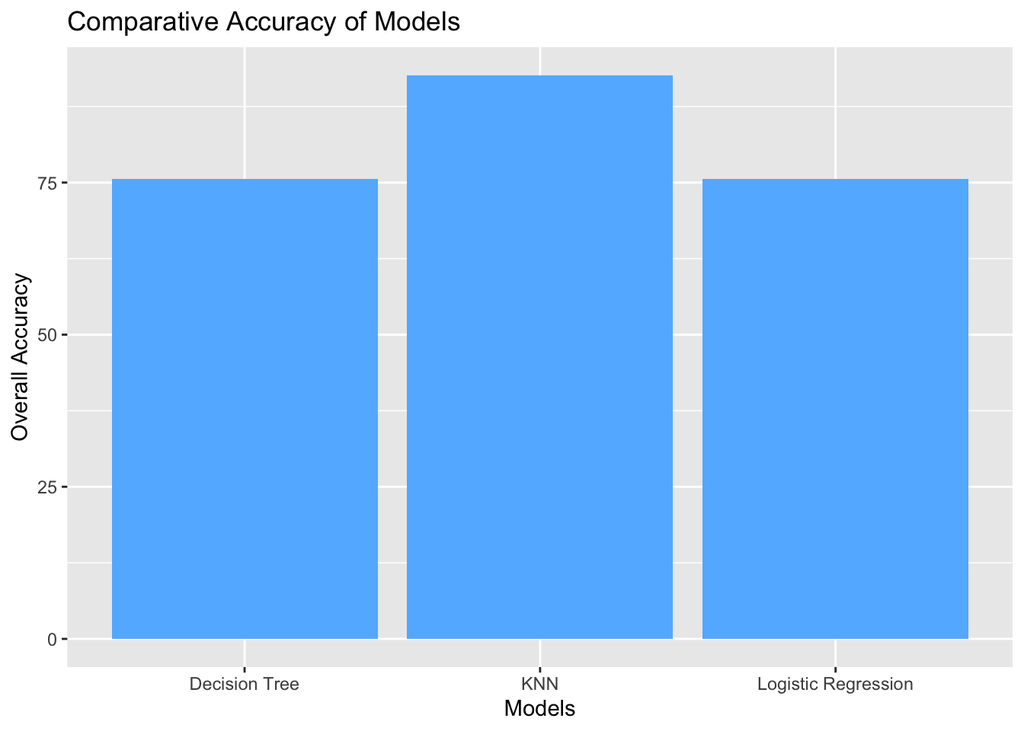

```r
ggplot(aes(x=Model, y=Accuracy), data=model_compare) +
    geom_bar(stat='identity', fill = 'steelblue1') +
    ggtitle('Comparative Accuracy of Models') +
    xlab('Models') +
    ylab('Overall Accuracy')
```

# Conclusion

The main question we are trying to answer with all the models is “Can we recommend certain songs to users who like to listen popular songs?”. According to our analysis, the answer will be “YES”. By using KNN model that we built, we can classify popular and unpopular song. Thus we can use this prediction model to recommend a certain song to users on Spotify who like to listen only popular songs.  
Through the exploratory data analysis, we can identify audio features which affect the popularity of songs to answer the first question. All the numerical variables such as danceability, energy, loudness, speechiness, acousticness, instrumentalness, liveness, valence, and tempo affect the popularity of songs since they have relationship with popularity statistically. For categorical variables, such as key, mode, and time signature, they are also dependent to popularity from the results of chi-squared tests.  
In a future project, we would like to include other features that we couldn’t explore this time like artist name or genre that heavily influence the popularity of a song in our analysis to acquire different insights.